# Obtención y procesamiento de datos de entrada

Alejandro Manuel Ferreiro

2022-05-23

# Registros de presencias

Los registros de presencia se obtuvieron de un extenso trabajo de campo realizado principalmente en Argentina, así como de visitas a colecciones mastozoológicas tanto de Argentina como de Bolivia. Esta base de datos se amplió haciendo una revisión profunda en la literatura, y de bases de datos abiertas tales como GBIF, VertNet y PaleoDB.

### Cargar puntos en R

Con todos ellos se armó una base de datos en una hoja de cálculo de excel, la cual se cargó en R de la siguiente manera:

```r
# Cargo los paquetes necesarios
library(readxl)
library(tidyverse)
library(sf)
library(tmap)
library(tmaptools)
```

```r
# Genero un tibble a partir del excel con los registros de presencia
rawOccs <- read.csv("Data/1_rawOcc.csv", sep = ";")
rawOccsSF = st_as_sf(rawOccs, coords = c("Longitud", "Latitud"), crs=4326)
summary(rawOccs)
```

```
##  NumColeccion           Pais            Provincia          Localidad
##  Length:399         Length:399         Length:399         Length:399
##  Class :character   Class :character   Class :character   Class :character
##  Mode  :character   Mode  :character   Mode  :character   Mode  :character
##
##
##
##  FechaColecta          Latitud          Longitud      Temporalidad
##  Length:399         Min.   :-40.78   Min.   :-67.47   Length:399
##  Class :character   1st Qu.:-27.08   1st Qu.:-62.96   Class :character
##  Mode  :character   Median :-23.36   Median :-61.88   Mode  :character
##                     Mean   :-24.64   Mean   :-61.75
##                     3rd Qu.:-20.23   3rd Qu.:-60.03
##                     Max.   :-16.08   Max.   :-52.87
##     Origen          Bibliografia          X             X.1
##  Length:399         Length:399         Mode:logical   Mode:logical
##  Class :character   Class :character   NA's:399       NA's:399
##  Mode  :character   Mode  :character
##
##
##
##    X.2
##  Mode:logical
##  NA's:399
##
##
##
##
```

Se separaron los registros de acuerdo a su temporalidad en Actual, Histórico, Holocénico y Pleistocénico. y a su vez consversion de puntos de presencia a objeto espacial “sf”.

```r
# Filtro registros actuales
rawOccsActual = rawOccs %>% filter(Temporalidad == "Actual")
rawOccsActualSF = st_as_sf(rawOccsActual, coords = c("Longitud", "Latitud"), crs = 4326)
# Filtro registros historico
rawOccsHistorico = rawOccs %>% filter(Temporalidad == "Historico")
rawOccsHistoricoSF = st_as_sf(rawOccsHistorico, coords = c("Longitud", "Latitud"), crs = 4326)
# Filtro registros holocenicos
rawOccsHoloceno = rawOccs %>% filter(Temporalidad == "Holoceno")
rawOccsHolocenoSF = st_as_sf(rawOccsHoloceno, coords = c("Longitud", "Latitud"), crs = 4326)
# Filtro registros historico
rawOccsPleistoceno = rawOccs %>% filter(Temporalidad == "Pleistoceno")
rawOccsPleistocenoSF = st_as_sf(rawOccsPleistoceno, coords = c("Longitud", "Latitud"), crs = 4326)
```

# Area M

Para evitar el sobreajuste del modelo, las capas de calibración se recortaron usando una máscara con una estimación del área accesible (M) para la especie. Esta se determinó utilizando un mapa de [ecoregiones](https://www.worldwildlife.org/publications/terrestrial-ecoregions-of-the-world) (Olson, 2001) e incluyó todas las ecorregiones donde se encontró un registro de esta especie. Como estas ecorregiones representan sólo patrones actuales, se consideró un área buffer de 1° de latitud/longitud para tener en cuenta los cambios en estas regiones en el pasado.

```r
## Ecoregiones (Olson, 2001)
Ecoregion = st_read("Data/EcoregionesOlson2001/wwf_terr_ecos.shp")
```

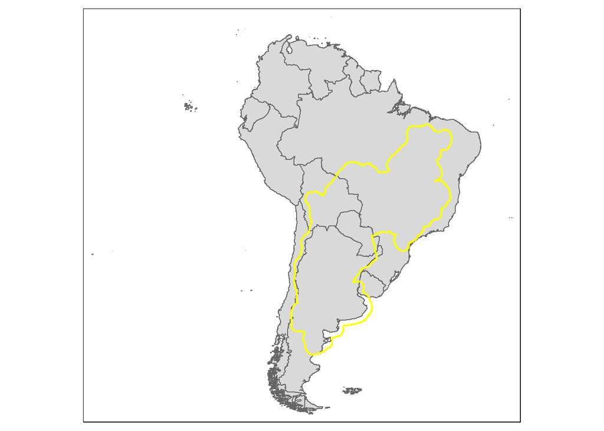

```r
Ecoregion = Ecoregion %>% filter(REALM == "NT")
EcoregionSF = st_as_sf(Ecoregion)
EcoregionSF = st_transform(EcoregionSF, 4326)
# Me quedo solo con ecoregiones del neotropico
# Genero poligono con ecoregiones donde hay registros
sf_use_s2(FALSE)
AreaMsinBuffer = EcoregionSF[rawOccsSF, ]
AreaM = AreaMsinBuffer %>% st_buffer( dist = 1) %>% st_union()
# Ploteo para ver como quedo en relacion a Sudamerica
PaisesSudamerica = rnaturalearth::ne_countries(scale = 10, continent = "south america", returnclass = "sf")
tm_shape(PaisesSudamerica) + tm_polygons() +
  tm_shape(AreaM) + tm_borders(col = "yellow", lwd = 2)
```

# Mapas

Con el fin de observar la distribución geográfica de los registros crudos (sin filtrado espacial), los grafico en mapas por temporalidad, usando como capas base las bioregiones para tiempos actuales e históricos, y limites politicos para Holoceno y Pleistoceno.

- Mapa con registros actuales

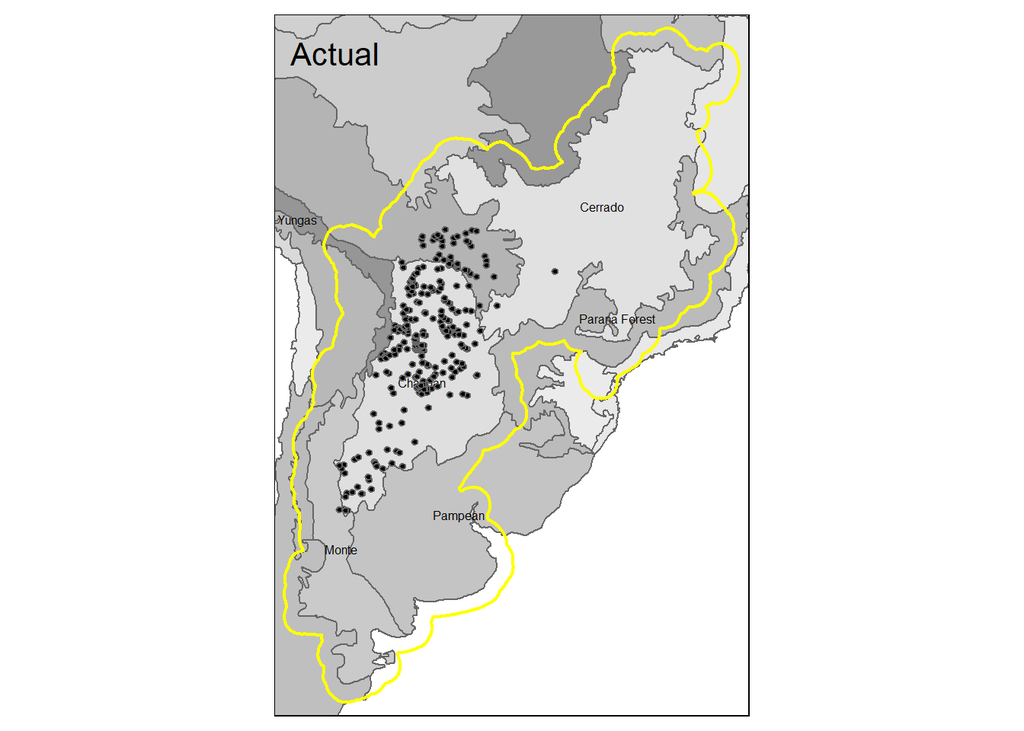

```r
# Mapa de bioregiones
BioregionMorrone = st_read("Data/BioregionesMorrone2014/Lowenberg_Neto_2014.shp")
BioregionMorrone = st_transform(BioregionMorrone, 4326)
BioregionMorroneLabels = BioregionMorrone %>%
  filter(Province_1=="Chacoan province" | Province_1=="Monte province" | Province_1=="Pampean province"
         | Province_1=="Yungas province" | Province_1=="Cerrado province" |Province_1=="Parana Forest province" ) %>%
  mutate(Province_1 = gsub(" province", "",Province_1)) %>%
  st_transform(crs = 4326)
## Mapas de registros actuales e historico se ploteron con Bioregiones como capa base
MapaBaseBioregion = tm_shape(BioregionMorrone, bbox = AreaM) + tm_polygons(col = "Province_1", palette = get_brewer_pal("Greys", n = 7, contrast = c(0.15, 0.5), plot = F), legend.show = F) +
tm_shape(AreaM) + tm_borders(col = "yellow", lwd = 2)+
  tm_shape(BioregionMorroneLabels) + tm_text("Province_1", size = 0.5)+
  tm_layout(title = "Actual",
            title.position = c("left", "top"),
            legend.position = c(0.7,0.05))

## Registros actuales
PresenciasActualMap =  MapaBaseBioregion +
  tm_shape(rawOccsActualSF) +  tm_symbols(size = 0.1, shape = 21,col = "black", alpha = 1)
PresenciasActualMap
```

- Mapa con registros historicos

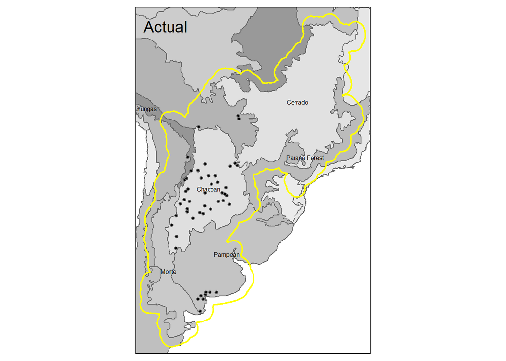

```r
## Registros actuales
PresenciasHistoricasMap =  MapaBaseBioregion +
  tm_shape(rawOccsHistoricoSF) +  tm_symbols(size = 0.1, shape = 21,col = "black", alpha = 1)
PresenciasHistoricasMap
```

- Mapa con registros del Holoceno

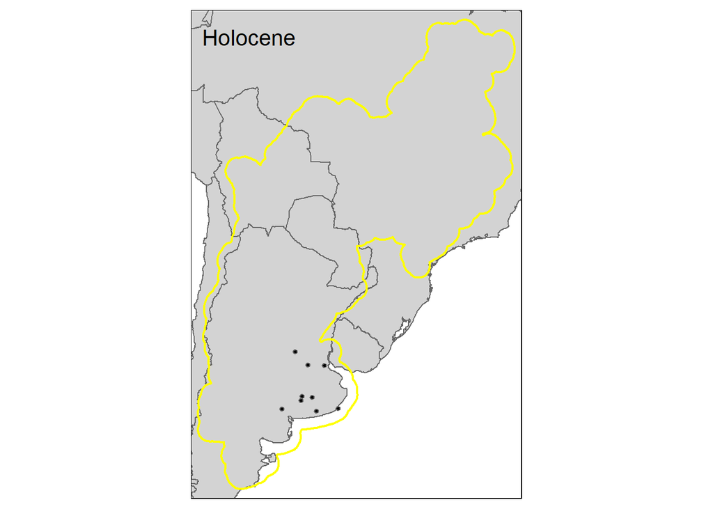

```r
# Mapa base límites políticos
# Mapa con registros del holoceno
MapaBasePolitico =  tm_shape(PaisesSudamerica, bbox = AreaM) + tm_polygons(col = "lightgrey") +
  tm_shape(AreaM) + tm_borders(col = "yellow", lwd = 2)
# Mapa con registros del Holoceno
PresenciasHolocenoMap = MapaBasePolitico +
  tm_shape(rawOccsHolocenoSF) +  tm_symbols(col = "black", size = 0.1, shape = 21) +
  tm_layout(title = "Holocene",
            title.position = c("left", "top"),
            legend.position = c(0.7,0.05))
PresenciasHolocenoMap
```

- Mapa con registros del Pleistoceno

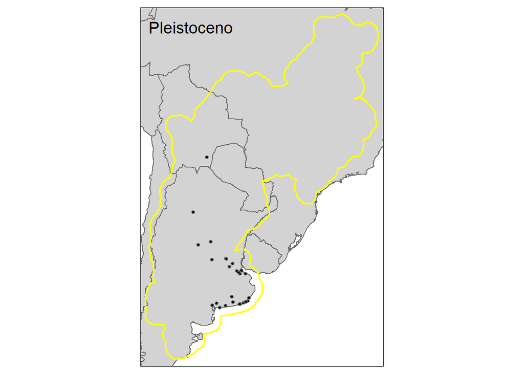

```r
# Mapa con registros del Holoceno
PresenciasPleistocenoMap = MapaBasePolitico +
  tm_shape(rawOccsPleistocenoSF) +  tm_symbols(col = "black", size = 0.1, shape = 21) +
  tm_layout(title = "Pleistoceno",
            title.position = c("left", "top"),
            legend.position = c(0.7,0.05))
PresenciasPleistocenoMap
```

Genero un mapa final y lo guardo como pdf para hacerle modificaciones esteticas en Inkscape

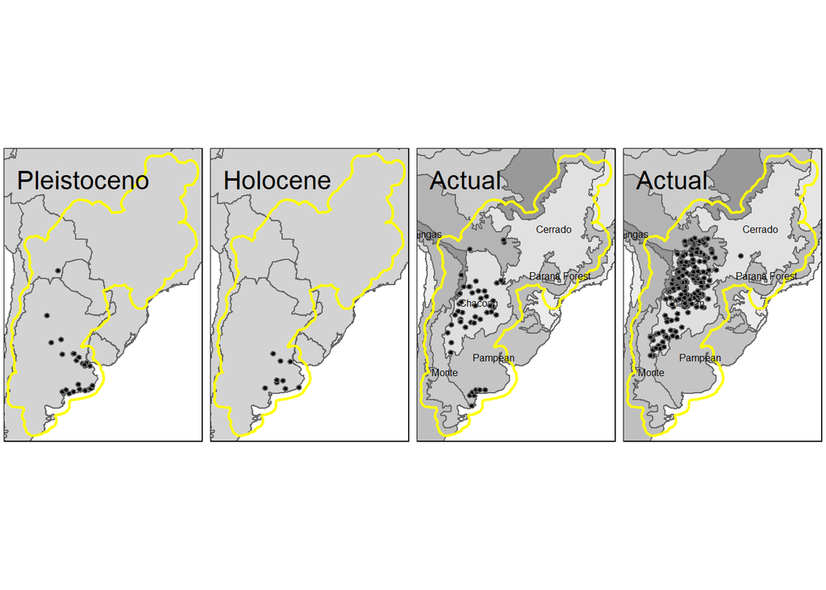

```r
# Grafico final
GraficoRawOccs = tmap_arrange(PresenciasPleistocenoMap, PresenciasHolocenoMap, PresenciasHistoricasMap, PresenciasActualMap,
                       nrow = 1, asp = NULL)
GraficoRawOccs
```

```r
# Guardo el mapa vectorizado para darle los retoques finales en Inkscape
tmap_save(GraficoRawOccs, "Figures/2_OccsMap.pdf")
```